# The University of the South (Sewanee, TN)

### US student origins

First time degree seeking undergrads

| State | Number of students | Fraction of student body from each state | Fraction of 18 year olds from each state enrolled here |
| --- | --- | --- | --- |
| Alabama | 45 | 1/9 | 1/1399 |
| Alaska | 0 | 0 | 0 |
| Arizona | 1 | 1/412 | 1/97724 |
| Arkansas | 6 | 1/69 | 1/6489 |
| California | 8 | 1/52 | 1/64408 |
| Colorado | 3 | 1/137 | 1/24439 |
| Connecticut | 5 | 1/82 | 1/10047 |
| Delaware | 1 | 1/412 | 1/12574 |
| Florida | 17 | 1/24 | 1/14242 |
| Georgia | 60 | 1/7 | 1/2371 |
| Hawaii | 1 | 1/412 | 1/14975 |
| Idaho | 1 | 1/412 | 1/24523 |
| Illinois | 3 | 1/137 | 1/53240 |
| Indiana | 0 | 0 | 0 |
| Iowa | 0 | 0 | 0 |
| Kansas | 1 | 1/412 | 1/39133 |
| Kentucky | 8 | 1/52 | 1/7129 |
| Louisiana | 10 | 1/41 | 1/5802 |
| Maine | 0 | 0 | 0 |
| Maryland | 10 | 1/41 | 1/7876 |
| Massachusetts | 5 | 1/82 | 1/19561 |
| Michigan | 1 | 1/412 | 1/132973 |
| Minnesota | 1 | 1/412 | 1/70682 |
| Mississippi | 3 | 1/137 | 1/13302 |
| Missouri | 2 | 1/206 | 1/37032 |
| Montana | 0 | 0 | 0 |
| Nebraska | 0 | 0 | 0 |
| Nevada | 1 | 1/412 | 1/35313 |
| New Hampshire | 1 | 1/412 | 1/17322 |
| New Jersey | 0 | 0 | 0 |
| New Mexico | 1 | 1/412 | 1/27661 |
| New York | 2 | 1/206 | 1/122508 |
| North Carolina | 29 | 1/14 | 1/4882 |
| North Dakota | 0 | 0 | 0 |
| Ohio | 3 | 1/137 | 1/50547 |
| Oklahoma | 4 | 1/103 | 1/12685 |
| Oregon | 1 | 1/412 | 1/49389 |
| Pennsylvania | 3 | 1/137 | 1/55524 |
| Rhode Island | 1 | 1/412 | 1/15844 |
| South Carolina | 21 | 1/20 | 1/2936 |
| South Dakota | 0 | 0 | 0 |
| Tennessee | 83 | 1/5 | 1/1009 |
| Texas | 36 | 1/11 | 1/11148 |
| Utah | 0 | 0 | 0 |
| Vermont | 0 | 0 | 0 |
| Virginia | 30 | 1/14 | 1/3646 |
| Washington | 2 | 1/206 | 1/44368 |
| West Virginia | 1 | 1/412 | 1/21161 |
| Wisconsin | 1 | 1/412 | 1/75165 |
| Wyoming | 0 | 0 | 0 |

### Library resources

|  | Number | Number per undergrad |
| --- | --- | --- |
| Number of physical books | 522,116 | 309 |
| Number of physical media | 116,949 | 69 |
| Number of physical serials | 4,136 | 3 |
| Number of digital/electronic books | 574,014 | 339 |
| Number of digital/electronic databases | 351 | 351 |
| Number of digital/electronic media | 233,719 | 138 |
| Number of electronic serials | 23,827 | 15 |
| Total library collections (physical and electronic) | 1,475,112 | 871 |
| Total physical library circulations (books and media) | 38,321 | 23 |
| Total digital/electronic circulations (books and media) | 83,030 | 49 |
| Total library circulations (physical and digital/electronic) | 121,351 | 72 |
| Total interlibrary loans and documents provided to other libraries | 3,652 | 3 |
| Total interlibrary loans and documents received | 4,028 | 3 |

## Figures

### Student to faculty ratio compared to similar institutions:

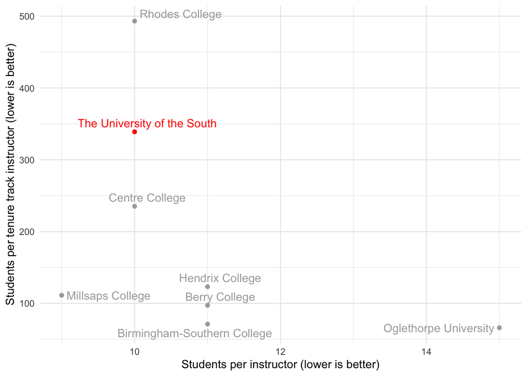

### Students from US

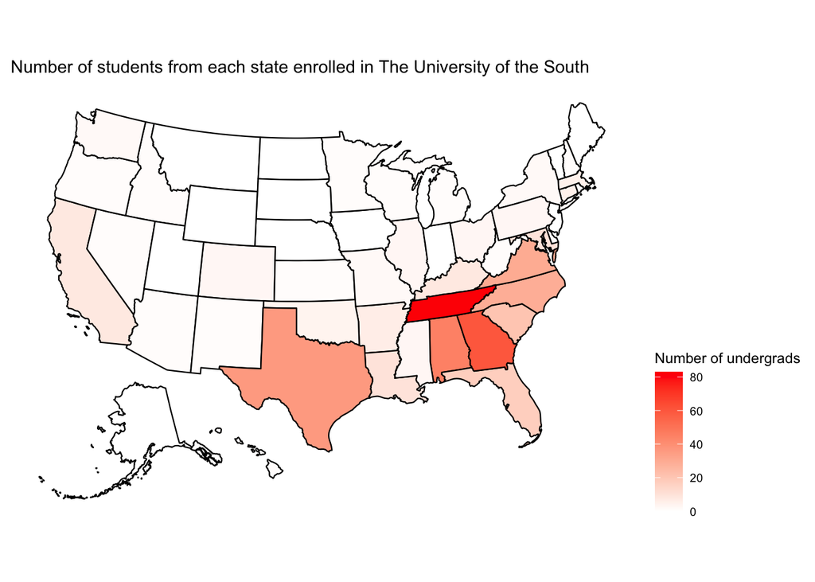

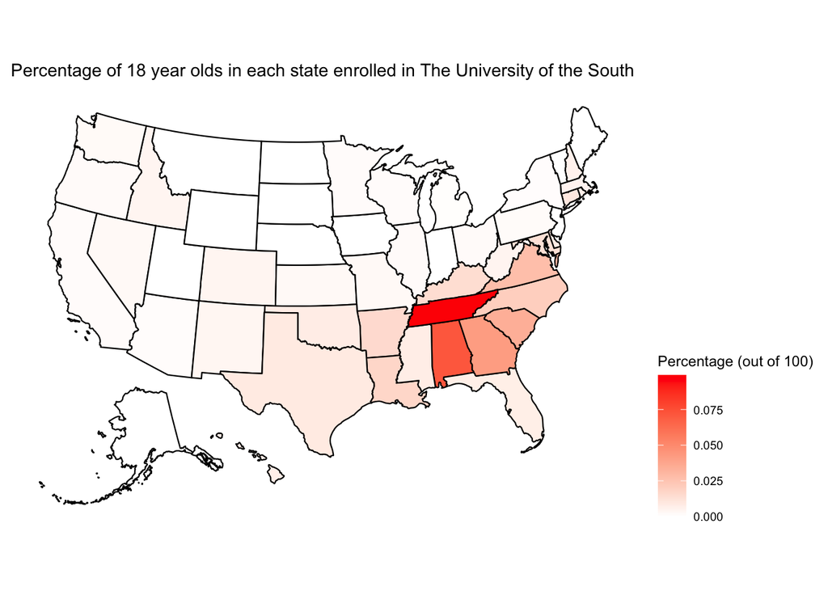